# I would like to offer you my opinion, which has absolutely no value in a project

## Project: tmdb-movies data analysis

- Introduction
- Data Wrangling
- Exploratory Data Analysis
- Conclusions

#### Introduction

> **Tip**:This is dataset of the 10,000 most popular movies across the world , This data set is fetched using exception handling process so the data set contains some null values as there are missing fields in the tmdb dataset,We will treat this data as such. -the data we collected consists of 10866 ROWs AND 21 COLUMNs ● Certain columns,"genres", contain multiple values separated by pipe (|) characters. ● The final two columns ending with "_adj" show the budget and revenue of the associated movie in terms of 2010 dollars,accounting for inflation over time.

##### Question To Be Answer:

1) How many movies based on their genres were produced?

2) Which genre got more cases hight and lower profit ?

4) which length movies most liked by the audiences according to their popularity?

5) Which director has made the most movies?

```python
# Use this cell to set up import statements for all of the packages that you
#   plan to use.

# Remember to include a 'magic word' so that your visualizations are plotted
#   inline with the notebook. See this page for more:
#   http://ipython.readthedocs.io/en/stable/interactive/magics.html
import numpy as np
import pandas as pd
import seaborn as sns
import matplotlib.pyplot as plt



%matplotlib inline








df = pd.read_csv('tmdb-movies.csv')
df.head(3)
```

|  | id | imdb_id | popularity | budget | revenue | original_title | cast | homepage | director | tagline | ... | overview | runtime | genres | production_companies | release_date | vote_count | vote_average | release_year | budget_adj | revenue_adj |
| --- | --- | --- | --- | --- | --- | --- | --- | --- | --- | --- | --- | --- | --- | --- | --- | --- | --- | --- | --- | --- | --- |
| 0 | 135397 | tt0369610 | 32.985763 | 150000000 | 1513528810 | Jurassic World | Chris Pratt\|Bryce Dallas Howard\|Irrfan Khan\|Vi... | http://www.jurassicworld.com/ | Colin Trevorrow | The park is open. | ... | Twenty-two years after the events of Jurassic ... | 124 | Action\|Adventure\|Science Fiction\|Thriller | Universal Studios\|Amblin Entertainment\|Legenda... | 6/9/15 | 5562 | 6.5 | 2015 | 1.379999e+08 | 1.392446e+09 |
| 1 | 76341 | tt1392190 | 28.419936 | 150000000 | 378436354 | Mad Max: Fury Road | Tom Hardy\|Charlize Theron\|Hugh Keays-Byrne\|Nic... | http://www.madmaxmovie.com/ | George Miller | What a Lovely Day. | ... | An apocalyptic story set in the furthest reach... | 120 | Action\|Adventure\|Science Fiction\|Thriller | Village Roadshow Pictures\|Kennedy Miller Produ... | 5/13/15 | 6185 | 7.1 | 2015 | 1.379999e+08 | 3.481613e+08 |
| 2 | 262500 | tt2908446 | 13.112507 | 110000000 | 295238201 | Insurgent | Shailene Woodley\|Theo James\|Kate Winslet\|Ansel... | http://www.thedivergentseries.movie/#insurgent | Robert Schwentke | One Choice Can Destroy You | ... | Beatrice Prior must confront her inner demons ... | 119 | Adventure\|Science Fiction\|Thriller | Summit Entertainment\|Mandeville Films\|Red Wago... | 3/18/15 | 2480 | 6.3 | 2015 | 1.012000e+08 | 2.716190e+08 |

3 rows × 21 columns

# Data Wrangling

## First assessing our Data

> **Tip**: In this section of the report, you will load in the data, check for cleanliness, and then trim and clean your dataset for analysis. Make sure that you document your steps carefully and justify your cleaning decisions.

### General Properties

```python
# Load your data and print out a few lines. Perform operations to inspect data
#   types and look for instances of missing or possibly errant data.
df.tail(3)
```

|  | id | imdb_id | popularity | budget | revenue | original_title | cast | homepage | director | tagline | ... | overview | runtime | genres | production_companies | release_date | vote_count | vote_average | release_year | budget_adj | revenue_adj |
| --- | --- | --- | --- | --- | --- | --- | --- | --- | --- | --- | --- | --- | --- | --- | --- | --- | --- | --- | --- | --- | --- |
| 10863 | 39768 | tt0060161 | 0.065141 | 0 | 0 | Beregis Avtomobilya | Innokentiy Smoktunovskiy\|Oleg Efremov\|Georgi Z... | NaN | Eldar Ryazanov | NaN | ... | An insurance agent who moonlights as a carthie... | 94 | Mystery\|Comedy | Mosfilm | 1/1/66 | 11 | 6.5 | 1966 | 0.000000 | 0.0 |
| 10864 | 21449 | tt0061177 | 0.064317 | 0 | 0 | What's Up, Tiger Lily? | Tatsuya Mihashi\|Akiko Wakabayashi\|Mie Hama\|Joh... | NaN | Woody Allen | WOODY ALLEN STRIKES BACK! | ... | In comic Woody Allen's film debut, he took the... | 80 | Action\|Comedy | Benedict Pictures Corp. | 11/2/66 | 22 | 5.4 | 1966 | 0.000000 | 0.0 |
| 10865 | 22293 | tt0060666 | 0.035919 | 19000 | 0 | Manos: The Hands of Fate | Harold P. Warren\|Tom Neyman\|John Reynolds\|Dian... | NaN | Harold P. Warren | It's Shocking! It's Beyond Your Imagination! | ... | A family gets lost on the road and stumbles up... | 74 | Horror | Norm-Iris | 11/15/66 | 15 | 1.5 | 1966 | 127642.279154 | 0.0 |

3 rows × 21 columns

```python
# this returns the datatypes of the columns

df.info()
```

```
<class 'pandas.core.frame.DataFrame'>
RangeIndex: 10866 entries, 0 to 10865
Data columns (total 21 columns):
id                      10866 non-null int64
imdb_id                 10856 non-null object
popularity              10866 non-null float64
budget                  10866 non-null int64
revenue                 10866 non-null int64
original_title          10866 non-null object
cast                    10790 non-null object
homepage                2936 non-null object
director                10822 non-null object
tagline                 8042 non-null object
keywords                9373 non-null object
overview                10862 non-null object
runtime                 10866 non-null int64
genres                  10843 non-null object
production_companies    9836 non-null object
release_date            10866 non-null object
vote_count              10866 non-null int64
vote_average            10866 non-null float64
release_year            10866 non-null int64
budget_adj              10866 non-null float64
revenue_adj             10866 non-null float64
dtypes: float64(4), int64(6), object(11)
memory usage: 1.7+ MB
```

```python
#  the dataset contain null values also
#count total rows in each column which contain null values

df.isnull().sum()
```

```
id                         0
imdb_id                   10
popularity                 0
budget                     0
revenue                    0
original_title             0
cast                      76
homepage                7930
director                  44
tagline                 2824
keywords                1493
overview                   4
runtime                    0
genres                    23
production_companies    1030
release_date               0
vote_count                 0
vote_average               0
release_year               0
budget_adj                 0
revenue_adj                0
dtype: int64
```

```python
# Descriptive statistics of the categorical columns. Gives interesting insights
df.describe(include=['object'])
```

|  | imdb_id | original_title | cast | homepage | director | tagline | keywords | overview | genres | production_companies | release_date |
| --- | --- | --- | --- | --- | --- | --- | --- | --- | --- | --- | --- |
| count | 10856 | 10866 | 10790 | 2936 | 10822 | 8042 | 9373 | 10862 | 10843 | 9836 | 10866 |
| unique | 10855 | 10571 | 10719 | 2896 | 5067 | 7997 | 8804 | 10847 | 2039 | 7445 | 5909 |
| top | tt0411951 | Hamlet | Louis C.K. | http://www.thehungergames.movie/ | Woody Allen | Based on a true story. | woman director | No overview found. | Drama | Paramount Pictures | 1/1/09 |
| freq | 2 | 4 | 6 | 4 | 45 | 5 | 134 | 13 | 712 | 156 | 28 |

```python
#  this returns a tuple of the dimensions of the dataframe
df.shape
```

```
(10866, 21)
```

# Second Data cleaning

> **Tip**: You should *not* perform too many operations in each cell. Create cells freely to explore your data. One option that you can take with this project is to do a lot of explorations in an initial notebook. These don't have to be organized, but make sure you use enough comments to understand the purpose of each code cell. Then, after you're done with your analysis, create a duplicate notebook where you will trim the excess and organize your steps so that you have a flowing, cohesive report.

> **Tip**: Make sure that you keep your reader informed on the steps that you are taking in your investigation. Follow every code cell, or every set of related code cells, with a markdown cell to describe to the reader what was found in the preceding cell(s). Try to make it so that the reader can then understand what they will be seeing in the following cell(s).

```python
# After discussing the structure of the data and any problems that need to be
## Cleaned, perform those cleaning steps in the second part of this section.
### First copy our data
ndf = df.copy()
```

```python
# show acolumns now
ndf.columns
```

```
Index(['id', 'imdb_id', 'popularity', 'budget', 'revenue', 'original_title',
       'cast', 'homepage', 'director', 'tagline', 'keywords', 'overview',
       'runtime', 'genres', 'production_companies', 'release_date',
       'vote_count', 'vote_average', 'release_year', 'budget_adj',
       'revenue_adj'],
      dtype='object')
```

# Cleaning, handling and data processing

# Choose data which will be using in our analysis

```python
#first cleaning all unnecessary info
ndf.drop(['homepage', 'tagline', 'keywords', 'overview', 'cast', 'imdb_id', 'budget', 'production_companies', 'revenue'], inplace = True, axis=1)
```

# Change type of date

## Remove duplicated raw

### Rename columns

#### Remove raws whose value budget_adj or revenue_adj ==0

##### Cleaning genres columns

```python
# Conver column 'release_date' types from object to datetime
ndf = ndf.astype({"release_date": "datetime64[ns]"})
```

```python
# checking a duplicated row
ndf.duplicated().sum()
```

```
1
```

```python
#Rmove duplicated one row
ndf.drop_duplicates(inplace = True)
```

```python
# checking a duplicated again
ndf.duplicated().sum()
```

```
0
```

```python
ndf.info()
```

```
<class 'pandas.core.frame.DataFrame'>
Int64Index: 10865 entries, 0 to 10865
Data columns (total 12 columns):
id                10865 non-null int64
popularity        10865 non-null float64
original_title    10865 non-null object
director          10821 non-null object
runtime           10865 non-null int64
genres            10842 non-null object
release_date      10865 non-null datetime64[ns]
vote_count        10865 non-null int64
vote_average      10865 non-null float64
release_year      10865 non-null int64
budget_adj        10865 non-null float64
revenue_adj       10865 non-null float64
dtypes: datetime64[ns](1), float64(4), int64(4), object(3)
memory usage: 1.1+ MB
```

```python
# rename columns
ndf.rename({"original_title": "Name_movie", "id": "id_movie"}, axis=1, inplace= True)
```

```python
# how much the columns values zero in 'revej' col and 'budj' col
# This deletion is completed by "selecting" rows where case numbers are non zero
ndf = ndf.loc[ndf['revenue_adj'] !=0]
ndf = ndf.loc[ndf['budget_adj'] !=0]
```

```python
ndf.describe()
```

|  | id_movie | popularity | runtime | vote_count | vote_average | release_year | budget_adj | revenue_adj |
| --- | --- | --- | --- | --- | --- | --- | --- | --- |
| count | 3854.000000 | 3854.000000 | 3854.000000 | 3854.000000 | 3854.000000 | 3854.000000 | 3.854000e+03 | 3.854000e+03 |
| mean | 39888.185262 | 1.191554 | 109.220291 | 527.720291 | 6.168163 | 2001.261028 | 4.423999e+07 | 1.370647e+08 |
| std | 67222.527399 | 1.475162 | 19.922820 | 879.956821 | 0.794920 | 11.282575 | 4.480925e+07 | 2.161114e+08 |
| min | 5.000000 | 0.001117 | 15.000000 | 10.000000 | 2.200000 | 1960.000000 | 9.693980e-01 | 2.370705e+00 |
| 25% | 6073.500000 | 0.462368 | 95.000000 | 71.000000 | 5.700000 | 1995.000000 | 1.309053e+07 | 1.835735e+07 |
| 50% | 11321.500000 | 0.797511 | 106.000000 | 204.000000 | 6.200000 | 2004.000000 | 3.001611e+07 | 6.173068e+07 |
| 75% | 38573.250000 | 1.368324 | 119.000000 | 580.000000 | 6.700000 | 2010.000000 | 6.061307e+07 | 1.632577e+08 |
| max | 417859.000000 | 32.985763 | 338.000000 | 9767.000000 | 8.400000 | 2015.000000 | 4.250000e+08 | 2.827124e+09 |

```python
ndf.shape
```

```
(3854, 12)
```

## Exploratory Data Analysis:- Explore what the histogram of the data looks like

> **Tip**: Now that you've trimmed and cleaned your data, you're ready to move on to exploration. Compute statistics and create visualizations with the goal of addressing the research questions that you posed in the Introduction section. It is recommended that you be systematic with your approach. Look at one variable at a time, and then follow it up by looking at relationships between variables.

[output not shown]

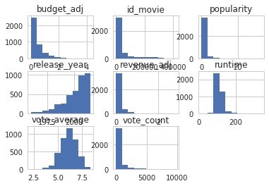

```python
# Use this, and more code cells, to explore your data. Don't forget to add
#   Markdown cells to document your observations and findings.
# show histogram of the dataset
ndf.hist()
```

# Research Question 1: How many movies based on their genres were produced?

```python
 #After cleaning the data now we will start extract the info. needed to answer our question
## first we will create a dictionary to collect all genres on the data set and to know how many movies produced.
genre_dict={}
genres_df = ndf['genres'].str.split("|")
genres_array = np.array(genres_df)
```

```python
for genrelist in genres_array:
    for genre in genrelist:
        if genre not in genre_dict:
            genre_dict[genre] = 1
        else:
            genre_dict[genre] += 1

sorted_genre=sorted(genre_dict.items(), key=lambda item: item[1], reverse = True)
```

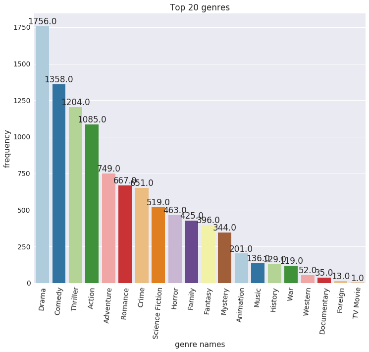

```python
x = list()
y = list()

for item in sorted_genre[0:20]:
    x.append(item[0])
    y.append(item[1])


sns.set(rc={'figure.figsize':(12,10)}, font_scale=1.4)
ax = sns.barplot(x=x, y=y, palette="Paired")
for p in ax.patches:
    ax.annotate(format(p.get_height(), '.1f'), (p.get_x() + p.get_width() / 2., p.get_height()), ha = 'center', va = 'center', xytext = (0, 9), textcoords = 'offset points')

#rotate x-axis' text
for item in ax.get_xticklabels():
    item.set_rotation(85)

    ax.set(xlabel='genre names', ylabel='frequency', title = 'Top 20 genres')

plt.show()
```

you can see here that Drama appears to be the most popular genre followed by Comedy & thriller movies

### Research Question 2 (Which genre got more cases hight and lower profit ?)

```python
# create new column
ndf['profit_J'] = ndf['revenue_adj'] - ndf['budget_adj']

#previewing the changes in the dataset
ndf.head(2)
```

|  | id_movie | popularity | Name_movie | director | runtime | genres | release_date | vote_count | vote_average | release_year | budget_adj | revenue_adj | profit_J |
| --- | --- | --- | --- | --- | --- | --- | --- | --- | --- | --- | --- | --- | --- |
| 0 | 135397 | 32.985763 | Jurassic World | Colin Trevorrow | 124 | Action\|Adventure\|Science Fiction\|Thriller | 2015-06-09 | 5562 | 6.5 | 2015 | 1.379999e+08 | 1.392446e+09 | 1.254446e+09 |
| 1 | 76341 | 28.419936 | Mad Max: Fury Road | George Miller | 120 | Action\|Adventure\|Science Fiction\|Thriller | 2015-05-13 | 6185 | 7.1 | 2015 | 1.379999e+08 | 3.481613e+08 | 2.101614e+08 |

```python
#defining the function
def calculate(column):
    #for highest earned profit
    high= ndf[column].idxmax()
    high_details=pd.DataFrame(ndf.loc[high])

    #for lowest earned profit
    low= ndf[column].idxmin()
    low_details=pd.DataFrame(ndf.loc[low])

    #collectin data in one place
    info=pd.concat([high_details, low_details], axis=1)

    return info

#calling the function
calculate('profit_J')
```

|  | 1329 | 2244 |
| --- | --- | --- |
| id_movie | 11 | 46528 |
| popularity | 12.0379 | 0.25054 |
| Name_movie | Star Wars | The Warrior's Way |
| director | George Lucas | Sngmoo Lee |
| runtime | 121 | 100 |
| genres | Adventure\|Action\|Science Fiction | Adventure\|Fantasy\|Action\|Western\|Thriller |
| release_date | 1977-03-20 00:00:00 | 2010-12-02 00:00:00 |
| vote_count | 4428 | 74 |
| vote_average | 7.9 | 6.4 |
| release_year | 1977 | 2010 |
| budget_adj | 3.95756e+07 | 4.25e+08 |
| revenue_adj | 2.78971e+09 | 1.10876e+07 |
| profit_J | 2.75014e+09 | -4.13912e+08 |

### Research Question 3: Average Popularity Of Movies From Year To Year?

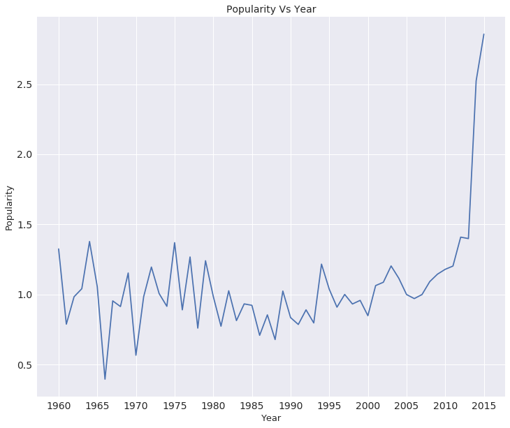

```python
#how the runtime of the movies differ year to year.

#make the group of the data according to their release_year and find the mean  related to this and plot.
ndf.groupby('release_year').mean()['popularity'].plot(xticks = np.arange(1960,2016,5))

#setup the figure size.
sns.set(rc={'figure.figsize':(10,5)})

#setup the title of the figure
plt.title("Popularity Vs Year",fontsize = 14)

#setup the x-label and y-label of the plot.
plt.xlabel('Year',fontsize = 13)
plt.ylabel('Popularity',fontsize = 13)
sns.set_style("whitegrid")
```

#### Research Question 4 : Which length movies most liked by the audiences according to their popularity?

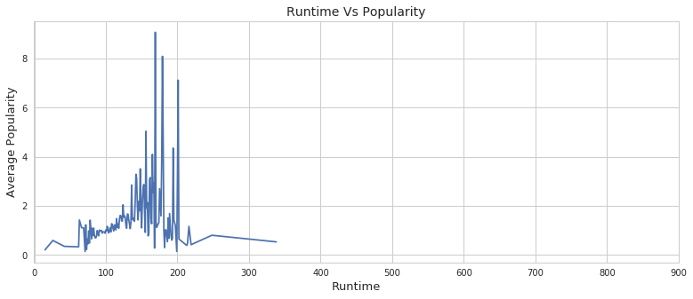

```python
#use groupby function and group the data according to their runtime.
#make a plot using their popularity and find which length movies are most popular.

#make the group of the data according to their runtime and find the mean popularity related to this and plot.
ndf.groupby('runtime')['popularity'].mean().plot(figsize = (13,5),xticks=np.arange(0,1000,100))

#setup the title of the figure
plt.title("Runtime Vs Popularity",fontsize = 14)

#setup the x-label and y-label of the plot.
plt.xlabel('Runtime',fontsize = 13)
plt.ylabel('Average Popularity',fontsize = 13)

#setup the figure size.
sns.set(rc={'figure.figsize':(10,5)})
sns.set_style("whitegrid")
```

##### Research Question 5: Which director has made the most movies?

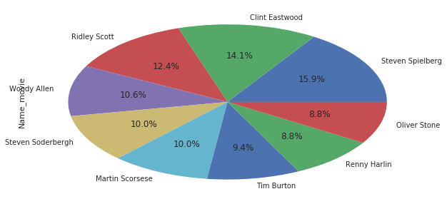

```python
#fetching different columns with 2 different ways of code
directors = ndf[["director", "Name_movie"]]

Top10_directors = directors.groupby("director")["Name_movie"].count().sort_values(ascending=False)[0:9]

Top10_directors.plot.pie(autopct="%.1f%%");
```

## Conclusions

> **Tip**: Finally, summarize your findings and the results that have been performed. Make sure that you are clear with regards to the limitations of your exploration. If you haven't done any statistical tests, do not imply any statistical conclusions. And make sure you avoid implying causation from correlation!

> **Tip**: Once you are satisfied with your work here, check over your report to make sure that it is satisfies all the areas of the rubric (found on the project submission page at the end of the lesson). You should also probably remove all of the "Tips" like this one so that the presentation is as polished as possible.

## Submitting your Project

> Before you submit your project, you need to create a .html or .pdf version of this notebook in the workspace here. To do that, run the code cell below. If it worked correctly, you should get a return code of 0, and you should see the generated .html file in the workspace directory (click on the orange Jupyter icon in the upper left).

> Alternatively, you can download this report as .html via the **File** > **Download as** submenu, and then manually upload it into the workspace directory by clicking on the orange Jupyter icon in the upper left, then using the Upload button.

> Once you've done this, you can submit your project by clicking on the "Submit Project" button in the lower right here. This will create and submit a zip file with this .ipynb doc and the .html or .pdf version you created. Congratulations!

```python
from subprocess import call
call(['python', '-m', 'nbconvert', 'Investigate_a_Dataset.ipynb'])
```

```
0
```